# Plotting in base R

Kenneth Tay

Oct 10, 2017

Even with the introduction of the `ggplot2` package, several R users still rely on base R (i.e. R without any user-installed packages) to create their plots. While the charts produced tend to be less fancy than their `ggplot2` counterparts, the syntax for base R can be very succinct. This is helpful when you are just exploring the data and are not too fussed about presentation.

For this document, we’ll use the built-in `mtcars` datset as a running example.

```r
data(mtcars)
head(mtcars)
```

```
##                    mpg cyl disp  hp drat    wt  qsec vs am gear carb
## Mazda RX4         21.0   6  160 110 3.90 2.620 16.46  0  1    4    4
## Mazda RX4 Wag     21.0   6  160 110 3.90 2.875 17.02  0  1    4    4
## Datsun 710        22.8   4  108  93 3.85 2.320 18.61  1  1    4    1
## Hornet 4 Drive    21.4   6  258 110 3.08 3.215 19.44  1  0    3    1
## Hornet Sportabout 18.7   8  360 175 3.15 3.440 17.02  0  0    3    2
## Valiant           18.1   6  225 105 2.76 3.460 20.22  1  0    3    1
```

## Scatterplot

Let’s say we are interested in the relationship between `mpg` and `wt`. We can make a scatterplot using the `plot` command, defining the `x` and `y` arguments of the function. (Recall that data frames are really just lists, so `mtcars$wt` refers to the `wt` element of `mtcars`, i.e. the values in the `wt` column.)

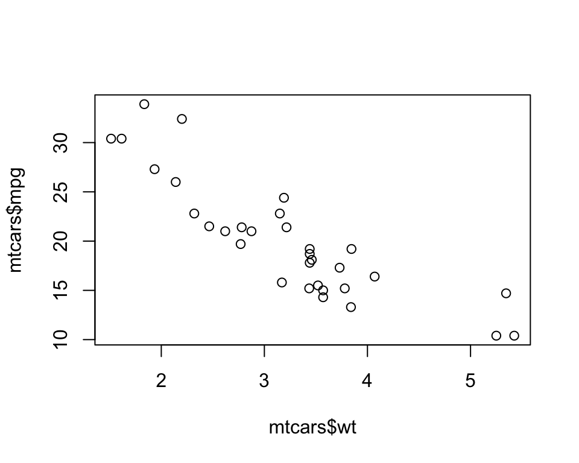

```r
plot(x = mtcars$wt, y = mtcars$mpg)
```

To have the points be represented by other shapes (instead of white circles), add the `pch` argument to `plot` (full list of shapes [here](http://www.cookbook-r.com/Graphs/Shapes_and_line_types/)):

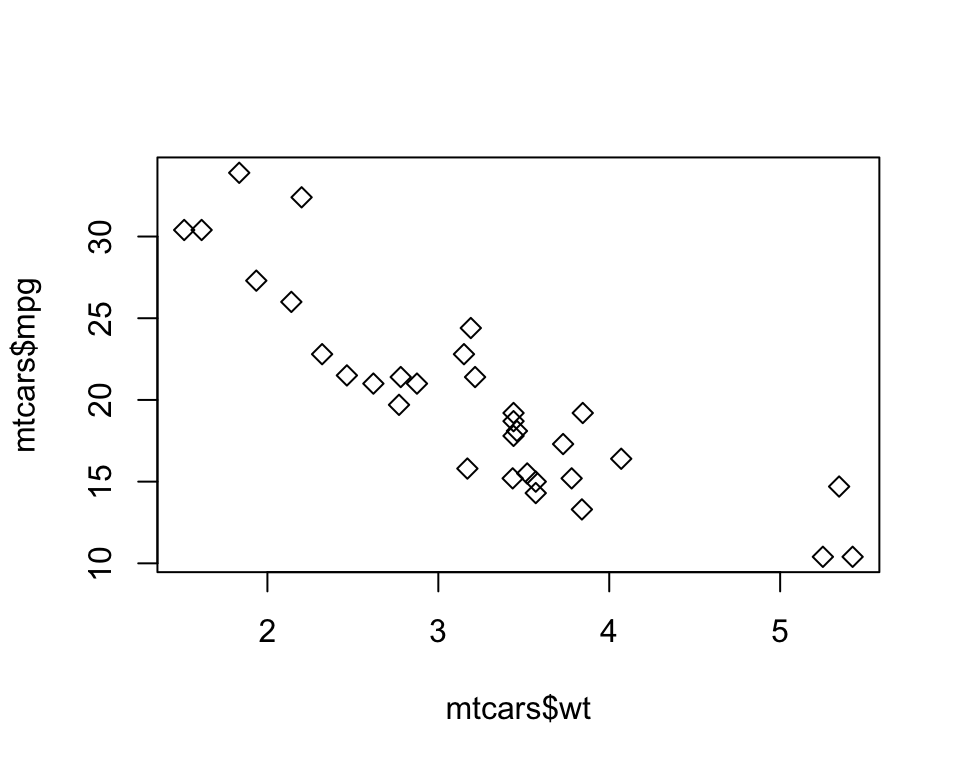

```r
plot(x = mtcars$wt, y = mtcars$mpg, pch = 5)
```

To change the size of the points, add the `cex` option to `plot` (1 is the default value):

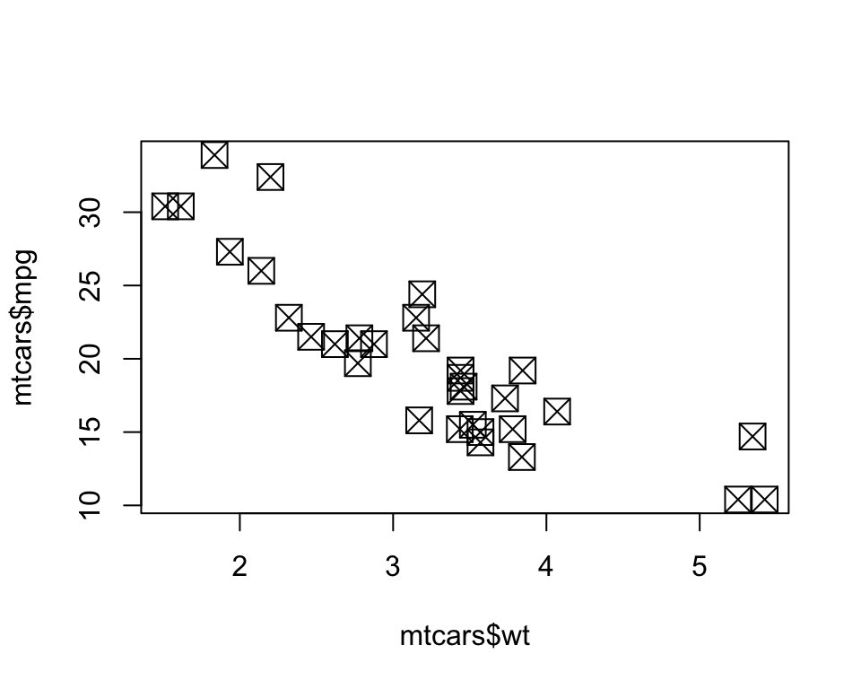

```r
plot(x = mtcars$wt, y = mtcars$mpg, pch = 7, cex = 2)
```

In some cases (e.g. time series data), we may want lines joining the data points instead of showing just the points themselves. To have lines instead of points, add `type = "l"` to the `plot` command. (Other options for `type` are “o”, “p” and “b”. Try them!)

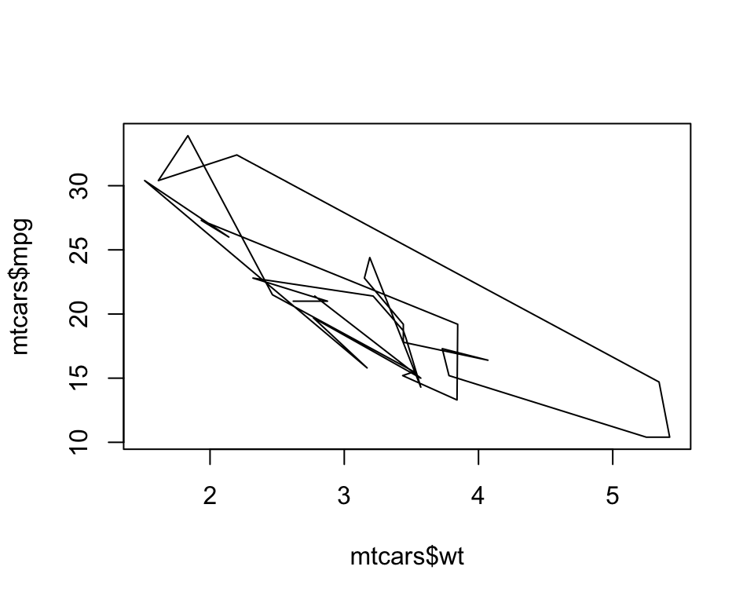

```r
plot(x = mtcars$wt, y = mtcars$mpg, type = "l")
```

(Drawing lines doesn’t really make sense in this context, so the above is simply for illustration.) We can have different types of lines by adding an `lty` option to plot (see [here](http://www.cookbook-r.com/Graphs/Shapes_and_line_types/) for more line options):

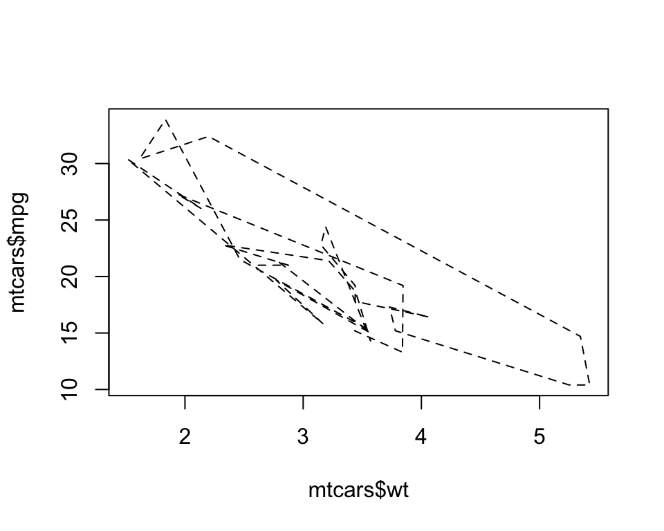

```r
plot(x = mtcars$wt, y = mtcars$mpg, type = "l", lty = "dashed")
```

For different line widths, use `lwd`:

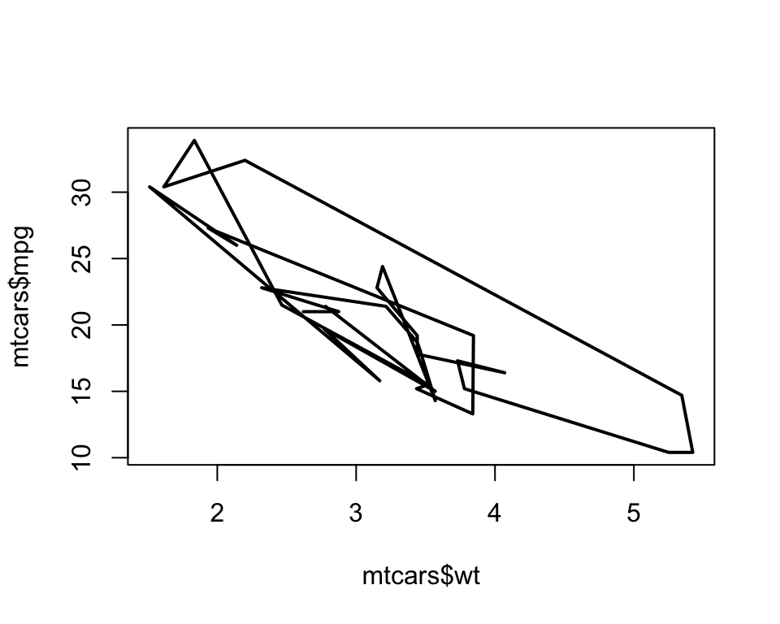

```r
plot(x = mtcars$wt, y = mtcars$mpg, type = "l", lwd = 2)
```

To change the color of the points, use the `col` option:

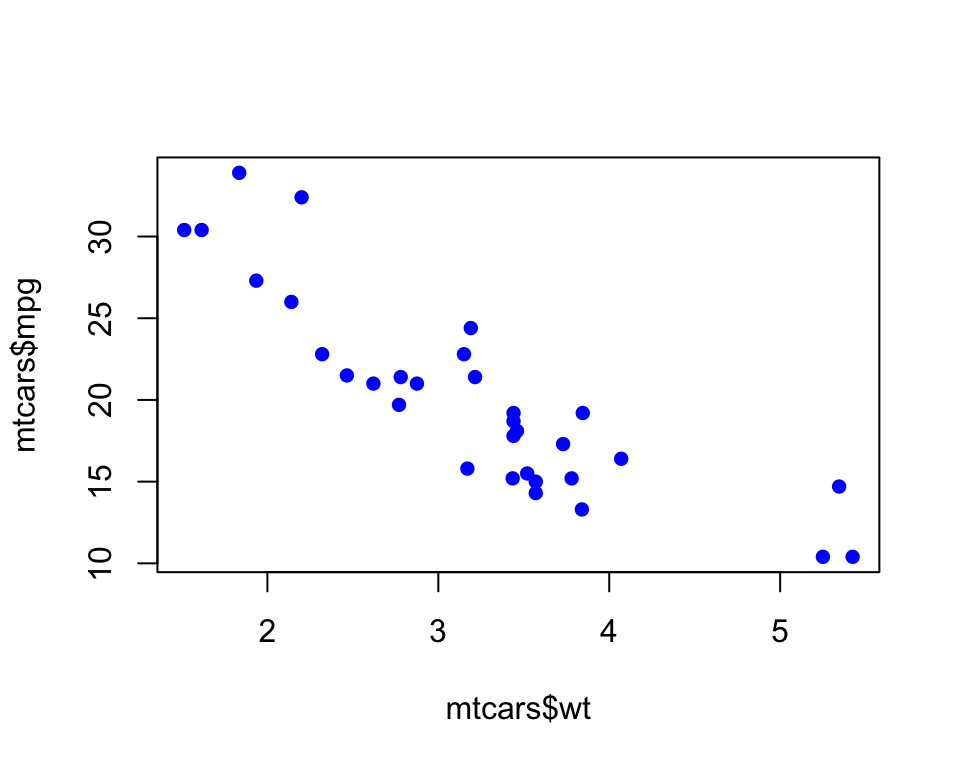

```r
plot(x = mtcars$wt, y = mtcars$mpg, pch = 16, col = "blue")
```

Like `ggplot2`, we can make the color of the point depend on which category it is in. Let’s say we want to color the points depending on the value of `cyl`. We first convert `cyl` to a factor, then modify the value of `col` in the `plot` call:

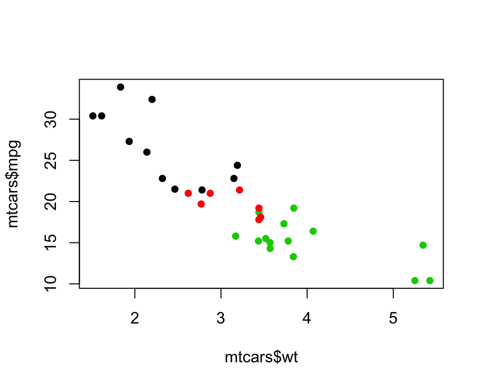

```r
mtcars$cyl <- factor(mtcars$cyl)
plot(x = mtcars$wt, y = mtcars$mpg, pch = 16, col = factor(mtcars$cyl))
```

To add a legend, follow the `plot` call with a `legend` call. The `x` and `y` options determine the top-left hand corner of the legend box. (Use the console to figure out what `levels(mtcars$cyl)` returns. Notice how you have to specify `col` and `pch` in the `legend` call as well. What happens if you don’t include them?)

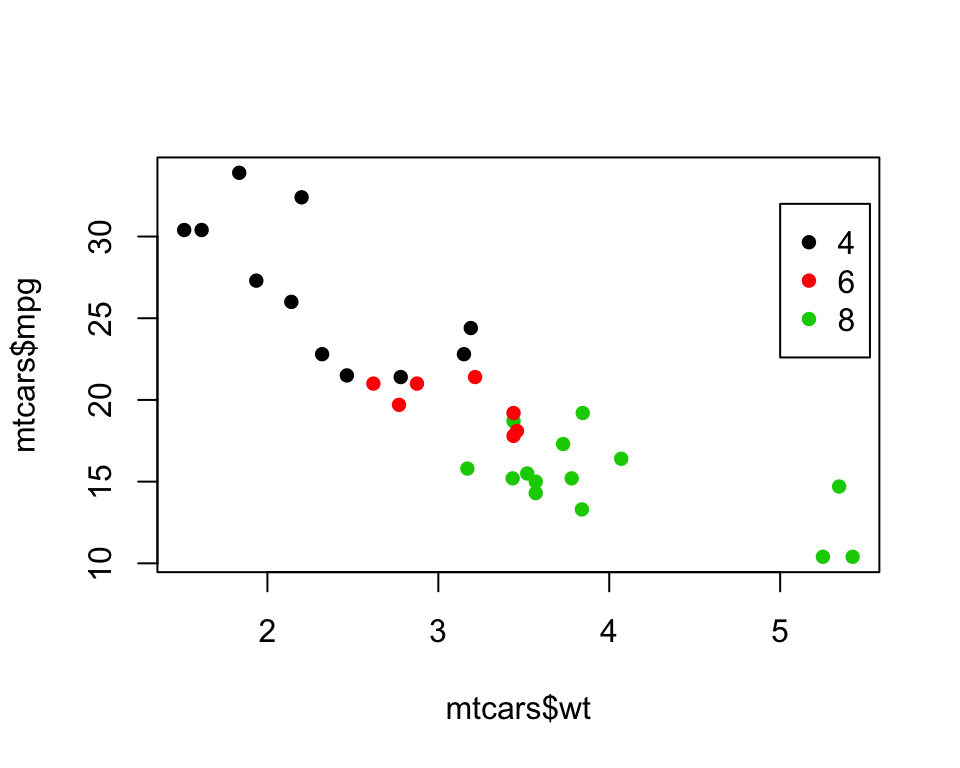

```r
plot(x = mtcars$wt, y = mtcars$mpg, pch = 16, col = mtcars$cyl)
legend(x = 5, y = 32, legend = levels(mtcars$cyl), col = c(1:3), pch = 16)
```

The code below shows how you can add titles and change the axis labels:

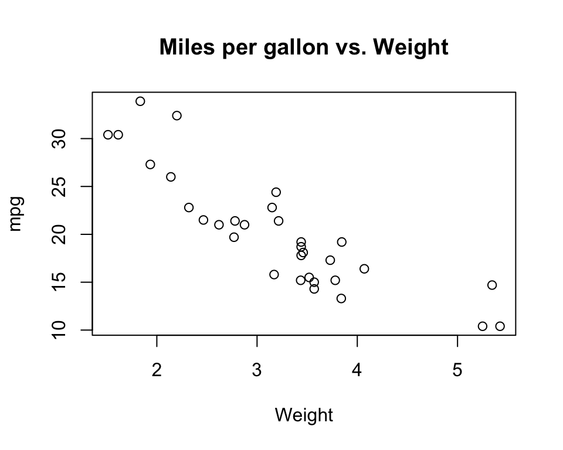

```r
plot(x = mtcars$wt, y = mtcars$mpg,
     main = "Miles per gallon vs. Weight", xlab = "Weight", ylab = "mpg")
```

To change the size of the title and the axis labels, use the `cex.main` and `cex.axis` options respectively.

## Histograms

A histogram shows the frequency count of one variable. To plot a histogram, use the `hist` command:

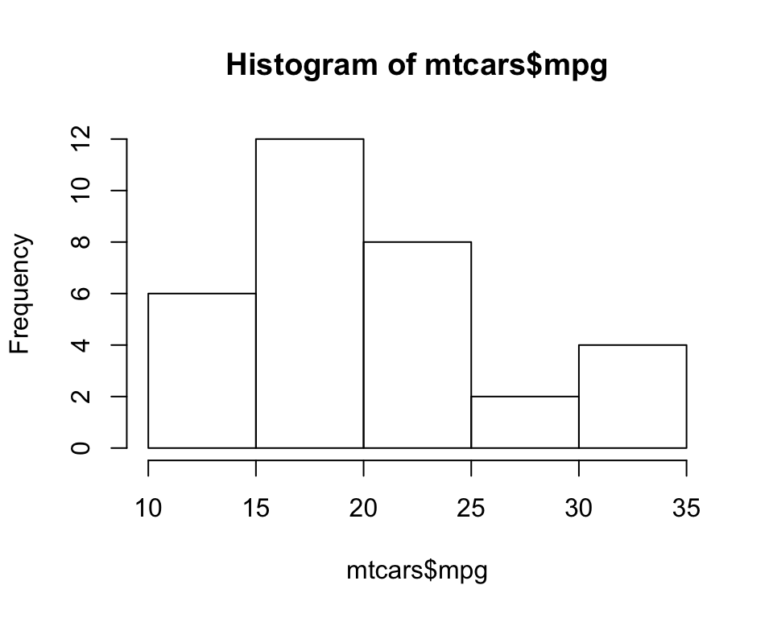

```r
hist(mtcars$mpg)
```

The number of bins is determined by an algorithm that R runs. If you want to specify the number of bins, you can use the `breaks` option and give it a number:

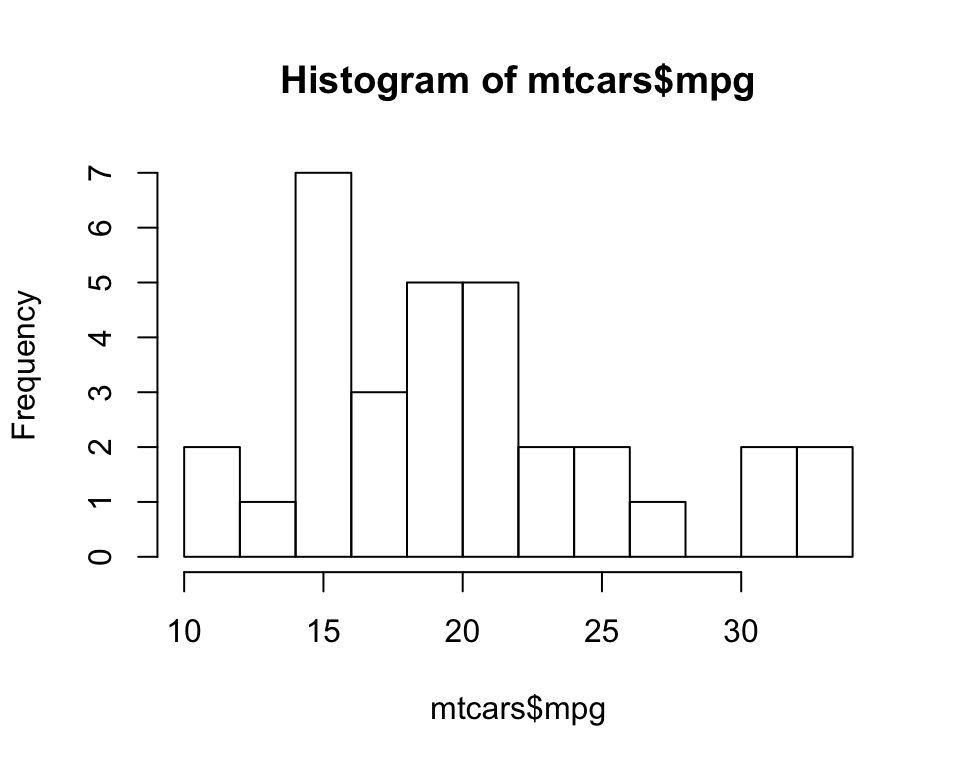

```r
hist(mtcars$mpg, breaks = 10)
```

Because of R’s algorithm for determining the number of bins, sometimes the number of bins you get doesn’t correspond exactly to the number you gave to `breaks`. To have exact control over this, instead of giving `breaks` an integer, you could give it a vector of “breakpoints” instead. For example, the code below bins the values into (10, 12], (12, 14], …, (32, 34]. (Type `?seq` to read the documentation for the `seq` function and figure out what it returns.)

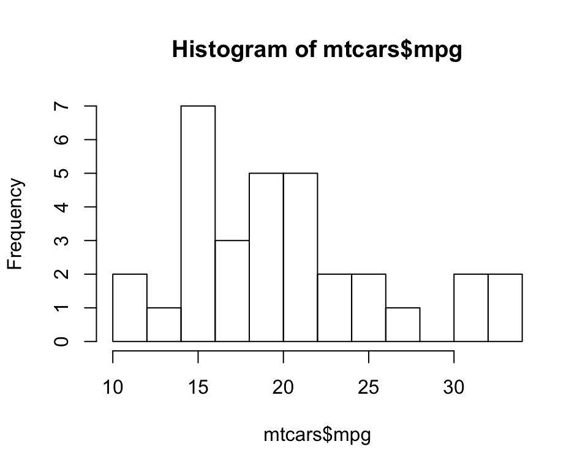

```r
hist(mtcars$mpg, breaks = seq(10, 34, by = 2))
```

## Boxplots

To make a boxplot, use `boxplot`:

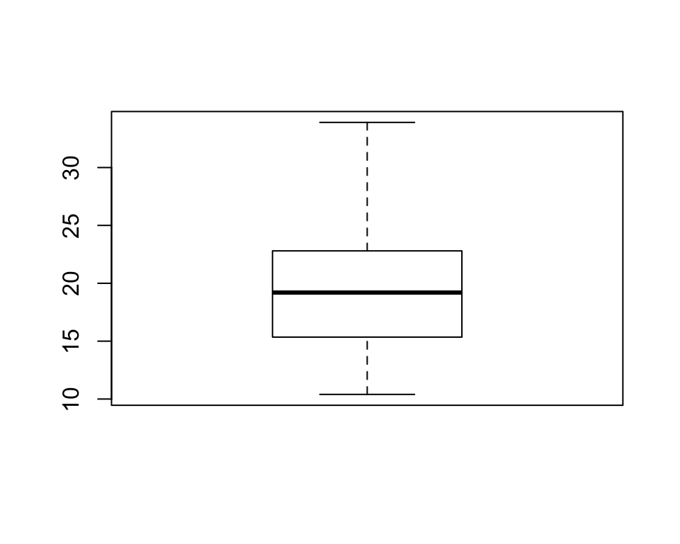

```r
boxplot(mtcars$mpg)
```

To make a boxplot for each category of `cyl` (the syntax is a little bit like that for `facet_wrap` and `facet_grid` in `ggplot2`):

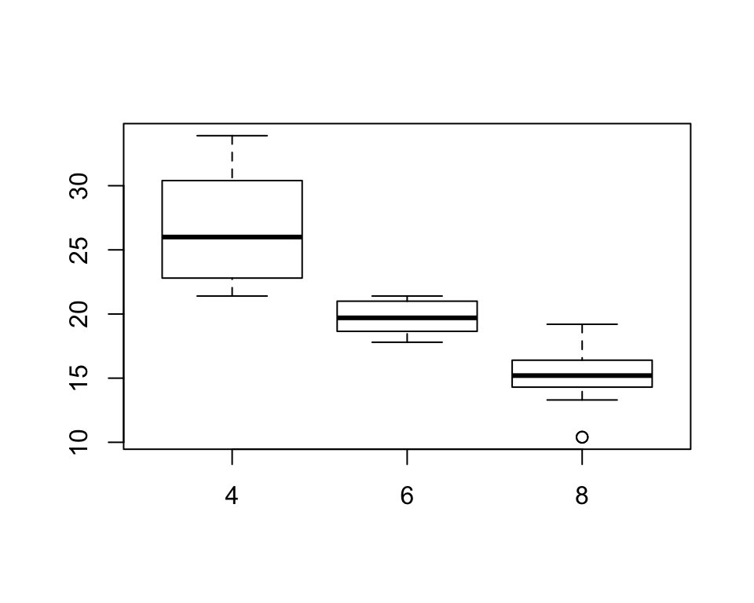

```r
boxplot(mtcars$mpg ~ mtcars$cyl)
```

Notice how the numbers on the y-axis are rotated. To make them as the numbers on the x-axis, use the `las` option:

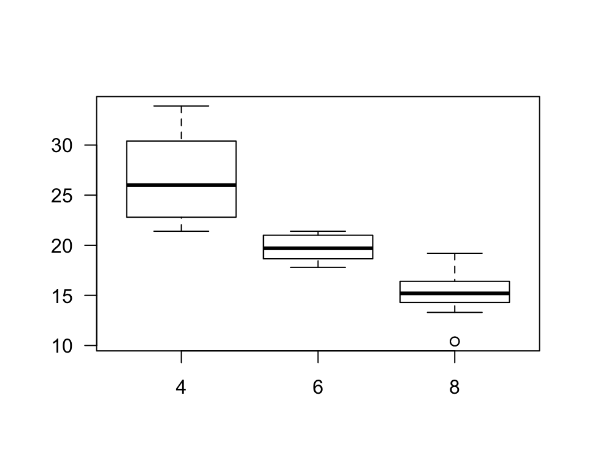

```r
boxplot(mtcars$mpg ~ mtcars$cyl, las = 1)
```

## Bar plots

If I want a bar plot showing how many rows there are for each value of `cyl`, I have to use the `table` function in conjunction with the `barplot` function. (What do you get if you use `plot` instead of `barplot`?)

```r
table(mtcars$cyl)
```

```
##
##  4  6  8
## 11  7 14
```

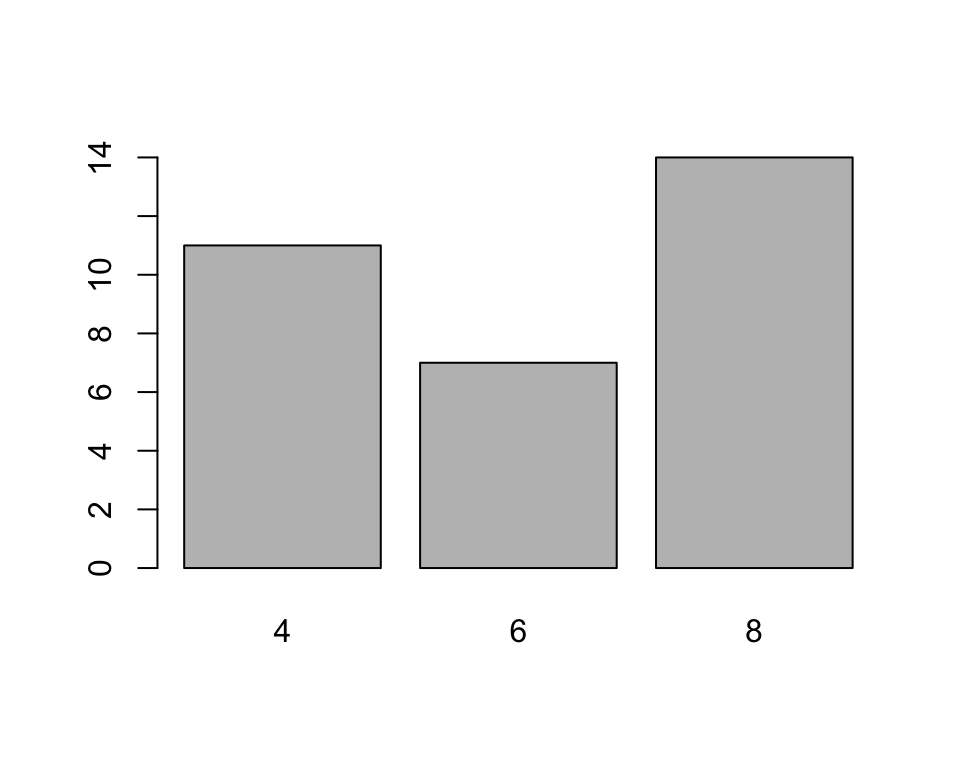

```r
barplot(table(mtcars$cyl))
```

## Conclusion

Plotting in base R can be very quick, even though the syntax may be harder to interpret and the outputs may look less professional.

Some other resources if you are interested in learning more about plotting in base R:

- [Base R cheatsheet](http://publish.illinois.edu/johnrgallagher/files/2015/10/BaseGraphicsCheatsheet.pdf)
- Longer tutorials: [here](http://www.statmethods.net/graphs/) and [here](https://www.harding.edu/fmccown/r/)
- A lot of googling around when you have a chart in mind but don’t know how to plot it